# Data Science Capstone Project: Milestone Report

Joy SN

January 18, 2019

## Introduction

The goal of this project is just to display that I have gott with the data and that I am on track to create your prediction algorithm. It should also explain the smy exploratory analysis of the data.

The data is from https://d396qusza40orc.cloudfront.net/dsscapstone/dataset/Coursera-SwiftKey.zip

3 Major Parts 1.Read and Sampling of Data 2. Cleaning and creating corpus of data 3. Creating NGrams

We analyse them using some graphs

## Reading and sampling input data

In this section, the file are readed and a sample is selected and save to avoid reading large files all the executions.

There are data for 4 languages - English (US), Finish, Russian, and From Denmark We are using only English Data. The sources are Blogs, Twitter and News Item

Size of the 3 Files - Blogs, News and Twitter

```
## [1] "US_blog file Size 200.42 Mb"
```

```
## [1] "US_news file Size 196.28 Mb"
```

```
## [1] "US_twitter file Size 159.36 Mb"
```

File Statistics of the 3 files - Blogs, News and Twitter

```
##       Lines LinesNEmpty       Chars CharsNWhite
##      899288      899288   208361438   171926076
```

[output not shown]

[output not shown]

Since the data are huge, we will sample the data (reading block chunks of 3000) and read only 5% of data Also, we store them into a new file and do not re-create them again

```r
set.seed(190130)
SampleFile<-function(fn) {
    paste("Reading 5% sample of file ",fn)
    fn_con=file(fn,open="r")
    DataFinal<-NULL
    LineChunk=3000
    longmaxline=0;
    while ( TRUE ) {
         line = readLines(fn_con, n = LineChunk,skipNul=TRUE)
         if ( length(line) == 0 ) {
             break
         }
         if(sample(1:20,1)==5)
         {
             DataFinal<-c(DataFinal,line)
         }
    }
    close(fn_con)
    return(DataFinal)
}
```

Details of the sample file generated

```
## [1] "General statistics Of Sampled Data"
```

```
##       Lines LinesNEmpty       Chars CharsNWhite
##      170259      170259    20633799    17038746
```

## Cleaning and creating corpus of data

### Corpus Creation

```r
CleanData <- VCorpus(VectorSource(DataSample))
```

### Data Cleanup

1. Remove white space
2. Remove Punctuation
3. Lower case
4. Remove Numbers stop words and URLs
5. Remove bad words

```r
CleanData <- tm_map(CleanData, content_transformer(tolower))
CleanData <- tm_map(CleanData, content_transformer(removePunctuation))
CleanData <- tm_map(CleanData, stripWhitespace)
CleanData <- tm_map(CleanData, removeWords, stopwords("english"))
CleanData <- tm_map(CleanData, removeNumbers)
removeURL <- function(x) gsub("http[[:alnum:]]*", "", x)
CleanData <- tm_map(CleanData,  content_transformer(removeURL))
profaneWords <- read.table("./bad-words_list.txt", header = FALSE)
CleanData <- tm_map(CleanData, removeWords, unlist(profaneWords))
```

## Creating NGrams

1. Create Tokenizer - Use Weka Package

```r
# Weka Package - Thank you. Creating 2,3 Tokens
BGTokenizer <- function(x) NGramTokenizer(x, Weka_control(min = 2, max = 2))
TGTokenizer <- function(x) NGramTokenizer(x, Weka_control(min = 3, max = 3))
```

2.Create the Matrices - Unigram, BiGram, TriGram

```r
# Unigram
DTMatrix<-DocumentTermMatrix(CleanData)
DTMatrixmatUni<-as.matrix(DTMatrix)
Ufreq<-colSums(DTMatrixmatUni)
Ufreq<-sort(Ufreq,decreasing = TRUE)

#BiGram
DTMatrixBG <- DocumentTermMatrix(CleanData, control = list(tokenize = BGTokenizer, stemming = TRUE))
DTMatrixBGMatrix<-as.matrix(DTMatrixBG)
BGFreq<-colSums(DTMatrixBGMatrix)
BGFreq<-sort(BGFreq,decreasing = TRUE)

#TriGram
DTMatrixTG <- DocumentTermMatrix(CleanData, control = list(tokenize = TGTokenizer, stemming = TRUE))
DTMatrixTGMatrix<-as.matrix(DTMatrixTG)
TGFreq<-colSums(DTMatrixTGMatrix)
TGFreq<-sort(TGFreq,decreasing = TRUE)
```

## Plots

### World Cloud - Thank you worldcloud

1. Top Single Words

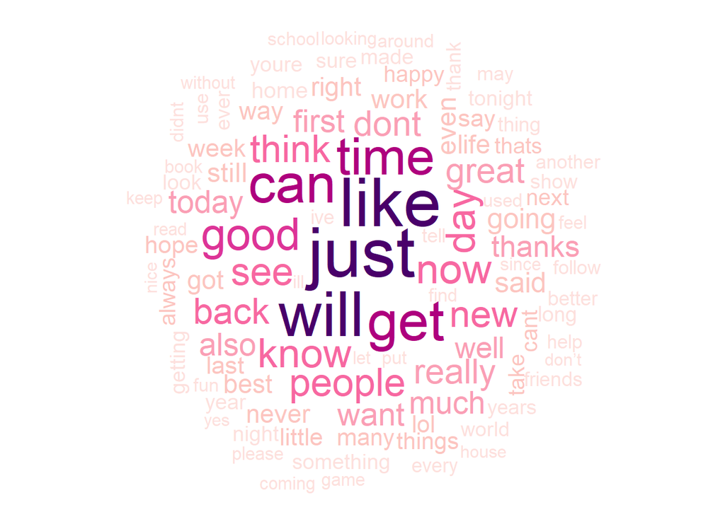

2. Top BiGrams

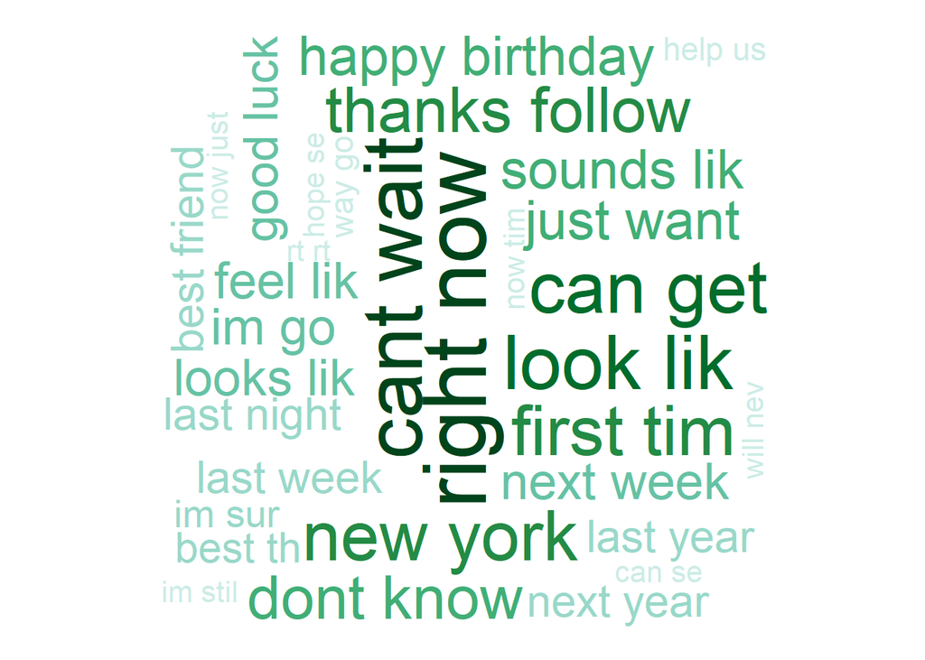

3. Top TriGrams

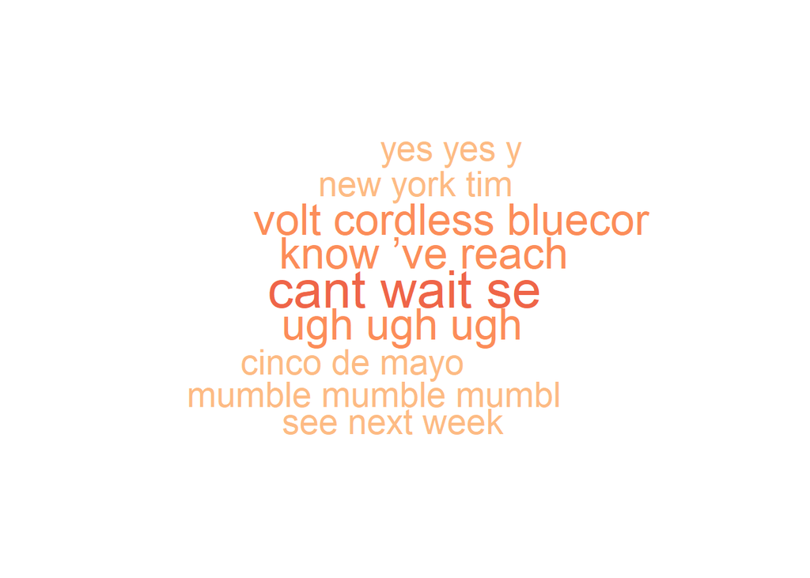

### 25 most frequent 1-2-3 gram words

1. Uni Gram

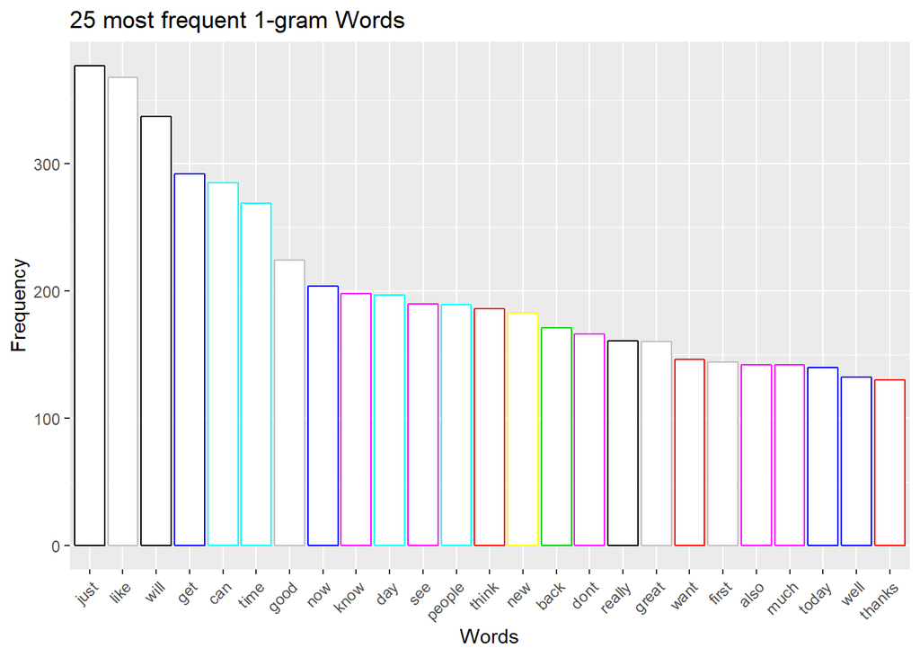

2. Bi-Gram

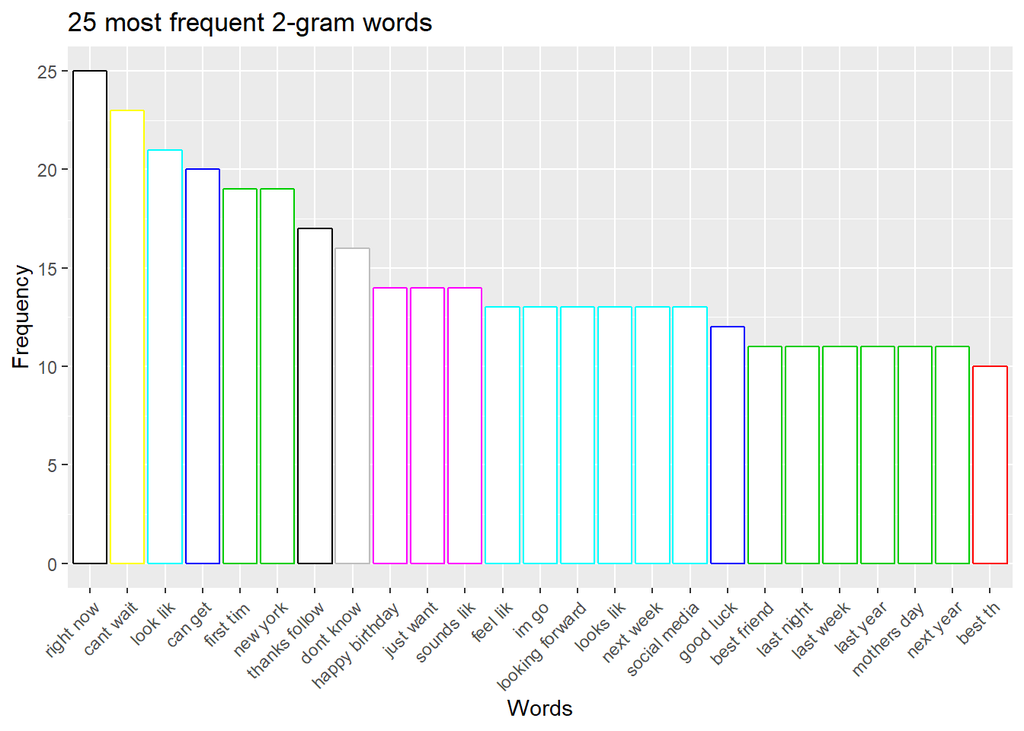

3. Tri-Gram

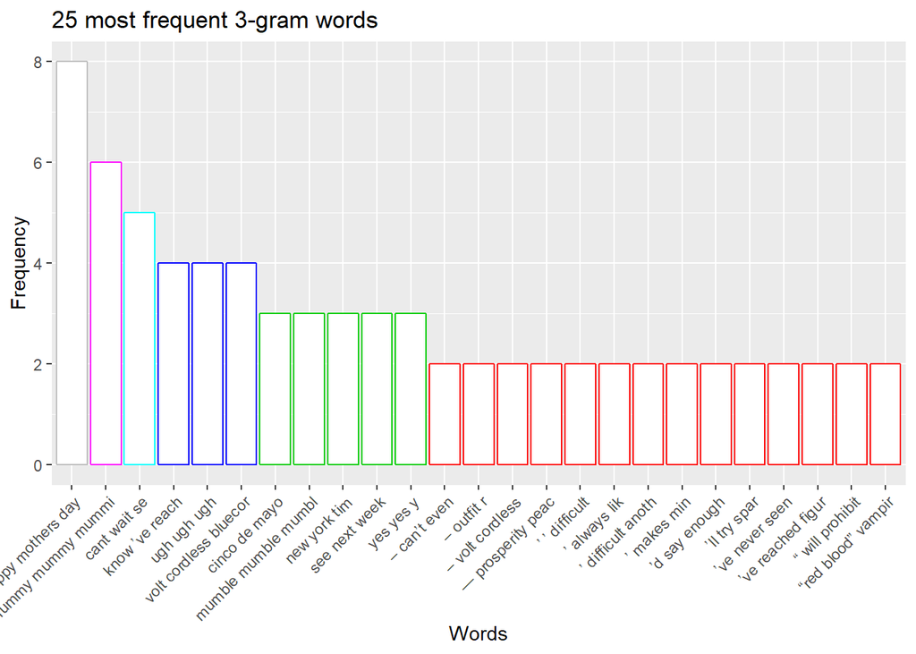

### Histogram

The dsitribution is skewed and it is expected

[figure not shown]

## Conclusions

Since the file sizes are huge and the application needs to be used in small devices as well, we needed to sample data from the corpus. That reduced the CPU, Memory as well as disk requirement. We have successfully build the 1,2 and 3grams.

## Next steps

We need to evaluate the performance of this Ngrams. Also use the Ngrams to build a predictive algorithm for writing a sentence.